# Practical Data Wrangling: Insights from 10,000 Rows of Dirty Cafe Sales Data

### **b. Determine Most Convenient Payment Options**.

Analyze the frequency of each payment method:

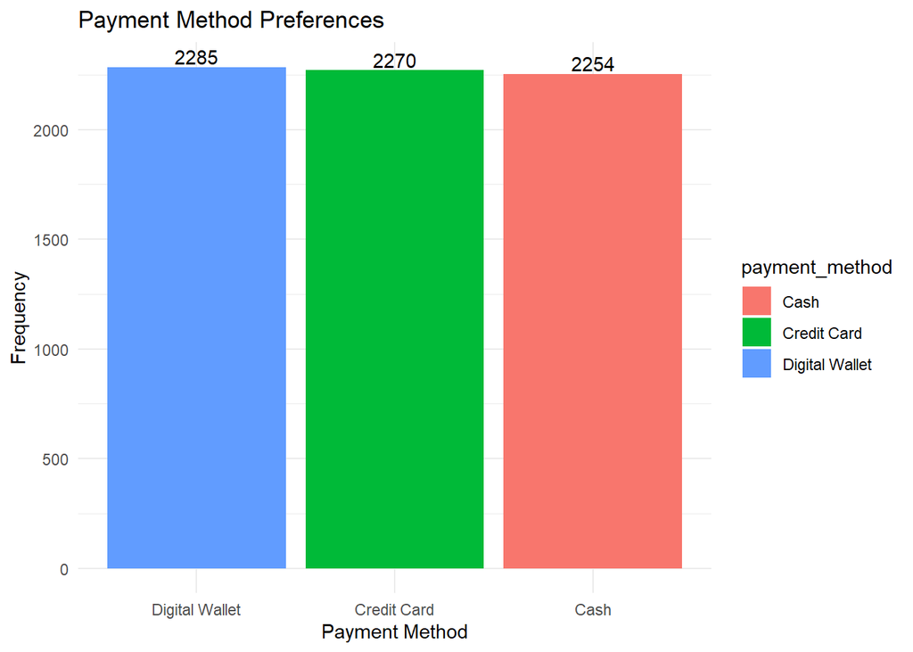

```r
# Count occurrences of payment methods
payment_preferences <- imputed_dataset %>%
  filter(!is.na(payment_method)) %>%
  group_by(payment_method) %>%
  summarize(count = n()) %>%
  arrange(desc(count))

#Plot

ggplot(payment_preferences, aes(x = reorder(payment_method, -count), y = count, fill = payment_method)) +
  geom_text(aes(label = count), vjust = -0.2) +
  geom_bar(stat = "identity") +
  labs(title = "Payment Method Preferences", x = "Payment Method", y = "Frequency") +
  theme_minimal()
```

#### **Preferred payment method is Digital Wallet.** **The cafe can consider doing the following:** *Ensure a seamless digital wallet payment experience by updating payment systems regularly.* *Offer discounts or loyalty points for payments made via digital wallets to encourage their use.* *Highlight cake promotions to boost sales further.*

#### **c. Analyze Seasonal Trends or Days with Higher Sales Activity** Look at sales trends over time (e.g., by day, month, or season):

```r
# Extract date parts
imputed_dataset %<>%
  mutate(day = weekdays(transaction_date),
         month = month(transaction_date, label = TRUE, abbr = TRUE),
         year = year(transaction_date))

# Analyze sales by day
daily_sales <- imputed_dataset %>%
  filter(!is.na(transaction_date)) %>%
  group_by(day) %>%
  summarize(total_sales = sum(total_spent, na.rm = TRUE)) %>%
  arrange(desc(total_sales))

# Analyze sales by month
monthly_sales <- imputed_dataset %>%
  filter(!is.na(transaction_date)) %>%
  group_by(month) %>%
  summarize(total_sales = sum(total_spent, na.rm = TRUE)) %>%
  arrange(desc(total_sales))

# View results
daily_sales
```

```
## # A tibble: 7 × 2
##   day       total_sales
##   <chr>           <dbl>
## 1 Thursday       12420.
## 2 Friday         12334
## 3 Sunday         12288.
## 4 Monday         12140
## 5 Saturday       12052.
## 6 Tuesday        12040.
## 7 Wednesday      11680.
```

```r
monthly_sales
```

```
## # A tibble: 12 × 2
##    month total_sales
##    <ord>       <dbl>
##  1 Jun         7353
##  2 Oct         7314
##  3 Jan         7254
##  4 Mar         7216
##  5 Dec         7195
##  6 Apr         7179
##  7 Aug         7112.
##  8 Nov         6967
##  9 May         6958.
## 10 Jul         6878.
## 11 Sep         6871
## 12 Feb         6656
```

#### Visualize daily trends:

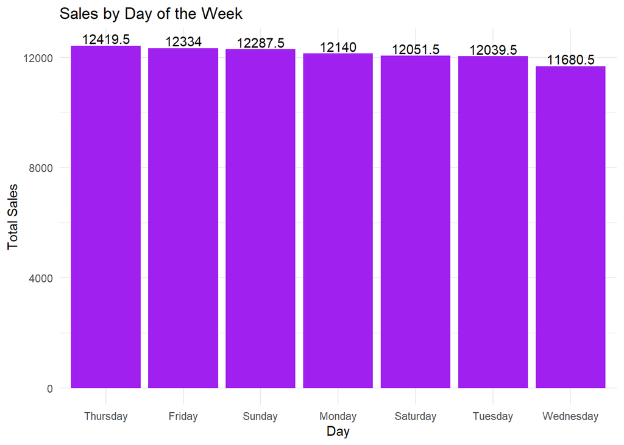

```r
# Daily trends
ggplot(daily_sales, aes(x = reorder(day, -total_sales), y = total_sales)) +
  geom_bar(stat = "identity", fill = "purple") +
  geom_text(aes(label = total_sales), vjust = -0.2) +
  labs(title = "Sales by Day of the Week", x = "Day", y = "Total Sales") +
  theme_minimal()
```

#### **Sales are highly active on Thursdays.** **The cafe can consider doing the following:** *Plan special promotions or events on Thursdays to Maximize sales.* *Optimize staff schedules to handle increased customer traffic on this day.* *Use targeted marketing campaigns to promote Thursday deals.*

#### Visualize monthly trends:

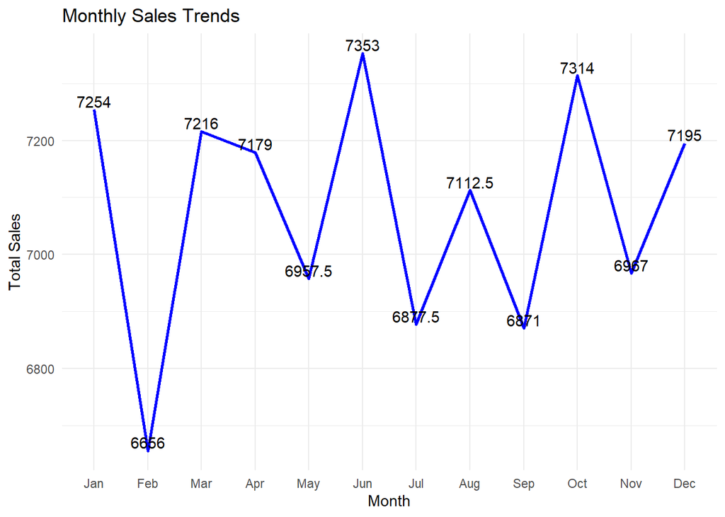

```r
# Monthly trends
ggplot(monthly_sales, aes(x = month, y = total_sales, group = 1)) +
  geom_line(color = "blue", size = 1) +
  geom_text(aes(label = total_sales), vjust = -0.2) +
  labs(title = "Monthly Sales Trends", x = "Month", y = "Total Sales") +
  theme_minimal()
```

#### **June is the peak month.** **The cafe can consider doing the following:** *Prepare for June by stocking up on popular products.* *Run summer-themed promotions or campaigns during this peak period.* *Analyze customer preferences in June to replicate strategies in other months.*

#### **d. Location Preferences for Strategic Marketing** Analyze sales distribution by location:

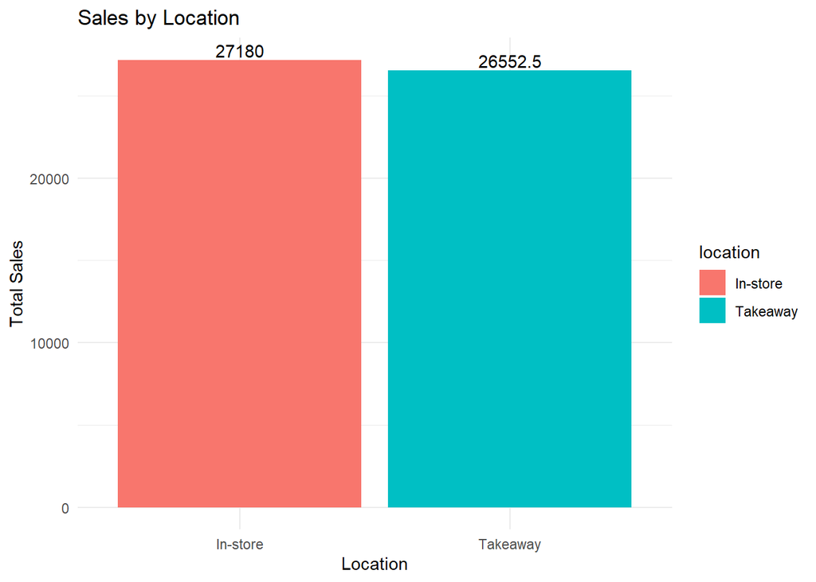

```r
# Sales by location
location_sales <- imputed_dataset %>%
  filter(!is.na(location)) %>%
  group_by(location) %>%
  summarize(total_sales = sum(total_spent, na.rm = TRUE)) %>%
  arrange(desc(total_sales))

#Plot

ggplot(location_sales, aes(x = reorder(location, -total_sales), y = total_sales, fill = location)) +
  geom_bar(stat = "identity") +
  geom_text(aes(label = total_sales), vjust = -0.2) +
  labs(title = "Sales by Location", x = "Location", y = "Total Sales") +
  theme_minimal()
```

#### **Customers prefer in-store dining.** **The cafe can consider doing the following:** *Enhance the in-store experience by improving seating, ambiance, and customer service.* *Introduce exclusive in-store-only offers programs.* *Gather customer feedback on in-store experiences to make further improvements.*